# (FordGoBike System Data)

## Introduction

Ford GoBike is the Bay Area's bike share system. In 2017, Ford GoBike will reinvent bike share in the Bay Area with 7,000 bikes across San Francisco, the East Bay and San Jose. Ford GoBike is expected to become an essential part of the Bay Area's transportation network.

Ford GoBike, like other bike share systems, consists of a fleet of specially designed, sturdy and durable bikes that are locked into a network of docking stations throughout the city. The bikes can be unlocked from one station and returned to any other station in the system, making them ideal for one-way trips. It's a fun, convenient and affordable way to get around.

The bikes are available for use 24 hours/day, 7 days/week, 365 days/year and riders have access to all bikes in the network when they become a member or purchase a pass.

## Preliminary Wrangling

```python
# import all packages and set plots to be embedded inline
import numpy as np
import pandas as pd
import matplotlib.pyplot as plt
import seaborn as sb

%matplotlib inline
import glob
import os
import datetime
```

```python
# Merging the files altogether to a single csv file
path = r'C:\Users\SADEEK\Udacity\2nd Part\Data Visualization\My Data'

files = glob.glob(os.path.join(path, "*.csv"))

df = pd.concat((pd.read_csv(f) for f in files), ignore_index = True)

df.to_csv('ford_bikes.csv', index = False)
```

```python
#Loading the dataset
df = pd.read_csv('ford_bikes.csv')
```

```python
#Showing the first 5 rows of the dataset
df.head()
```

|  | duration_sec | start_time | end_time | start_station_id | start_station_name | start_station_latitude | start_station_longitude | end_station_id | end_station_name | end_station_latitude | end_station_longitude | bike_id | user_type | member_birth_year | member_gender | bike_share_for_all_trip |
| --- | --- | --- | --- | --- | --- | --- | --- | --- | --- | --- | --- | --- | --- | --- | --- | --- |
| 0 | 75284 | 2018-01-31 22:52:35.2390 | 2018-02-01 19:47:19.8240 | 120.0 | Mission Dolores Park | 37.761420 | -122.426435 | 285.0 | Webster St at O'Farrell St | 37.783521 | -122.431158 | 2765 | Subscriber | 1986.0 | Male | No |
| 1 | 85422 | 2018-01-31 16:13:34.3510 | 2018-02-01 15:57:17.3100 | 15.0 | San Francisco Ferry Building (Harry Bridges Pl... | 37.795392 | -122.394203 | 15.0 | San Francisco Ferry Building (Harry Bridges Pl... | 37.795392 | -122.394203 | 2815 | Customer | NaN | NaN | No |
| 2 | 71576 | 2018-01-31 14:23:55.8890 | 2018-02-01 10:16:52.1160 | 304.0 | Jackson St at 5th St | 37.348759 | -121.894798 | 296.0 | 5th St at Virginia St | 37.325998 | -121.877120 | 3039 | Customer | 1996.0 | Male | No |
| 3 | 61076 | 2018-01-31 14:53:23.5620 | 2018-02-01 07:51:20.5000 | 75.0 | Market St at Franklin St | 37.773793 | -122.421239 | 47.0 | 4th St at Harrison St | 37.780955 | -122.399749 | 321 | Customer | NaN | NaN | No |
| 4 | 39966 | 2018-01-31 19:52:24.6670 | 2018-02-01 06:58:31.0530 | 74.0 | Laguna St at Hayes St | 37.776435 | -122.426244 | 19.0 | Post St at Kearny St | 37.788975 | -122.403452 | 617 | Subscriber | 1991.0 | Male | No |

```python
df.info()
```

```
<class 'pandas.core.frame.DataFrame'>
RangeIndex: 819164 entries, 0 to 819163
Data columns (total 16 columns):
duration_sec               819164 non-null int64
start_time                 819164 non-null object
end_time                   819164 non-null object
start_station_id           817103 non-null float64
start_station_name         817103 non-null object
start_station_latitude     819164 non-null float64
start_station_longitude    819164 non-null float64
end_station_id             817103 non-null float64
end_station_name           817103 non-null object
end_station_latitude       819164 non-null float64
end_station_longitude      819164 non-null float64
bike_id                    819164 non-null int64
user_type                  819164 non-null object
member_birth_year          760467 non-null float64
member_gender              760690 non-null object
bike_share_for_all_trip    819164 non-null object
dtypes: float64(7), int64(2), object(7)
memory usage: 100.0+ MB
```

```python
df.shape
```

```
(819164, 16)
```

```python
df.describe()
```

|  | duration_sec | start_station_id | start_station_latitude | start_station_longitude | end_station_id | end_station_latitude | end_station_longitude | bike_id | member_birth_year |
| --- | --- | --- | --- | --- | --- | --- | --- | --- | --- |
| count | 819164.000000 | 817103.000000 | 819164.000000 | 819164.000000 | 817103.000000 | 819164.000000 | 819164.000000 | 819164.000000 | 760467.000000 |
| mean | 879.605099 | 113.110619 | 37.767413 | -122.351751 | 111.284454 | 37.767557 | -122.351111 | 2187.603797 | 1982.102357 |
| std | 2576.385421 | 94.816424 | 0.103012 | 0.180935 | 94.562349 | 0.102895 | 0.180561 | 1188.942033 | 10.542897 |
| min | 61.000000 | 3.000000 | 37.312854 | -122.444293 | 3.000000 | 37.312854 | -122.444293 | 11.000000 | 1889.000000 |
| 25% | 350.000000 | 30.000000 | 37.771058 | -122.411726 | 30.000000 | 37.771058 | -122.410807 | 1182.000000 | 1977.000000 |
| 50% | 554.000000 | 81.000000 | 37.781270 | -122.397405 | 81.000000 | 37.781383 | -122.397380 | 2283.000000 | 1984.000000 |
| 75% | 870.000000 | 179.000000 | 37.795393 | -122.291360 | 178.000000 | 37.795812 | -122.291376 | 3209.000000 | 1990.000000 |
| max | 86366.000000 | 356.000000 | 45.510000 | -73.570000 | 356.000000 | 45.510000 | -73.570000 | 4307.000000 | 2000.000000 |

```python
#Checking for Null values
df.isnull().sum()
```

```
duration_sec                   0
start_time                     0
end_time                       0
start_station_id            2061
start_station_name          2061
start_station_latitude         0
start_station_longitude        0
end_station_id              2061
end_station_name            2061
end_station_latitude           0
end_station_longitude          0
bike_id                        0
user_type                      0
member_birth_year          58697
member_gender              58474
bike_share_for_all_trip        0
dtype: int64
```

```python
#Checking for duplicates
df.duplicated().sum()
```

```
0
```

### Cleaning

```python
#I will make a copy before the cleaning process
df_clean = df.copy()
```

##### Define: Change start_time and end_time to timestamp format

###### Code:

```python
df_clean.start_time = pd.to_datetime(df_clean.start_time)
df_clean.end_time = pd.to_datetime(df_clean.end_time)
```

###### Test

```python
df_clean.info()
```

```
<class 'pandas.core.frame.DataFrame'>
RangeIndex: 819164 entries, 0 to 819163
Data columns (total 16 columns):
duration_sec               819164 non-null int64
start_time                 819164 non-null datetime64[ns]
end_time                   819164 non-null datetime64[ns]
start_station_id           817103 non-null float64
start_station_name         817103 non-null object
start_station_latitude     819164 non-null float64
start_station_longitude    819164 non-null float64
end_station_id             817103 non-null float64
end_station_name           817103 non-null object
end_station_latitude       819164 non-null float64
end_station_longitude      819164 non-null float64
bike_id                    819164 non-null int64
user_type                  819164 non-null object
member_birth_year          760467 non-null float64
member_gender              760690 non-null object
bike_share_for_all_trip    819164 non-null object
dtypes: datetime64[ns](2), float64(7), int64(2), object(5)
memory usage: 100.0+ MB
```

##### Define: Change bike_id, start_station_id and end_station_id to string format

###### Code

```python
df_clean.bike_id = df_clean.bike_id.astype(str)
df_clean.start_station_id = df_clean.start_station_id.astype(str)
df_clean.end_station_id = df_clean.end_station_id.astype(str)
```

###### Test

```python
df_clean.info()
```

```
<class 'pandas.core.frame.DataFrame'>
RangeIndex: 819164 entries, 0 to 819163
Data columns (total 16 columns):
duration_sec               819164 non-null int64
start_time                 819164 non-null datetime64[ns]
end_time                   819164 non-null datetime64[ns]
start_station_id           819164 non-null object
start_station_name         817103 non-null object
start_station_latitude     819164 non-null float64
start_station_longitude    819164 non-null float64
end_station_id             819164 non-null object
end_station_name           817103 non-null object
end_station_latitude       819164 non-null float64
end_station_longitude      819164 non-null float64
bike_id                    819164 non-null object
user_type                  819164 non-null object
member_birth_year          760467 non-null float64
member_gender              760690 non-null object
bike_share_for_all_trip    819164 non-null object
dtypes: datetime64[ns](2), float64(5), int64(1), object(8)
memory usage: 100.0+ MB
```

#### Define: Change user_type and member_gender to category format

```python
df_clean.user_type = df_clean.user_type.astype('category')
df_clean.member_gender = df_clean.member_gender.astype('category')
```

###### Test

```python
df_clean.info()
```

```
<class 'pandas.core.frame.DataFrame'>
RangeIndex: 819164 entries, 0 to 819163
Data columns (total 16 columns):
duration_sec               819164 non-null int64
start_time                 819164 non-null datetime64[ns]
end_time                   819164 non-null datetime64[ns]
start_station_id           819164 non-null object
start_station_name         817103 non-null object
start_station_latitude     819164 non-null float64
start_station_longitude    819164 non-null float64
end_station_id             819164 non-null object
end_station_name           817103 non-null object
end_station_latitude       819164 non-null float64
end_station_longitude      819164 non-null float64
bike_id                    819164 non-null object
user_type                  819164 non-null category
member_birth_year          760467 non-null float64
member_gender              760690 non-null category
bike_share_for_all_trip    819164 non-null object
dtypes: category(2), datetime64[ns](2), float64(5), int64(1), object(6)
memory usage: 89.1+ MB
```

##### Define: Create the member age of each member from `member_birth_year` by subtracting their birth year from the current year (2020)

###### Code

```python
# Subtracting the member_birth_year from the current year to get the ages of the members
df_clean['member_age'] = 2020 - df_clean['member_birth_year']
```

###### Test

```python
df_clean.head()
```

|  | duration_sec | start_time | end_time | start_station_id | start_station_name | start_station_latitude | start_station_longitude | end_station_id | end_station_name | end_station_latitude | end_station_longitude | bike_id | user_type | member_birth_year | member_gender | bike_share_for_all_trip | member_age |
| --- | --- | --- | --- | --- | --- | --- | --- | --- | --- | --- | --- | --- | --- | --- | --- | --- | --- |
| 0 | 75284 | 2018-01-31 22:52:35.239 | 2018-02-01 19:47:19.824 | 120.0 | Mission Dolores Park | 37.761420 | -122.426435 | 285.0 | Webster St at O'Farrell St | 37.783521 | -122.431158 | 2765 | Subscriber | 1986.0 | Male | No | 34.0 |
| 1 | 85422 | 2018-01-31 16:13:34.351 | 2018-02-01 15:57:17.310 | 15.0 | San Francisco Ferry Building (Harry Bridges Pl... | 37.795392 | -122.394203 | 15.0 | San Francisco Ferry Building (Harry Bridges Pl... | 37.795392 | -122.394203 | 2815 | Customer | NaN | NaN | No | NaN |
| 2 | 71576 | 2018-01-31 14:23:55.889 | 2018-02-01 10:16:52.116 | 304.0 | Jackson St at 5th St | 37.348759 | -121.894798 | 296.0 | 5th St at Virginia St | 37.325998 | -121.877120 | 3039 | Customer | 1996.0 | Male | No | 24.0 |
| 3 | 61076 | 2018-01-31 14:53:23.562 | 2018-02-01 07:51:20.500 | 75.0 | Market St at Franklin St | 37.773793 | -122.421239 | 47.0 | 4th St at Harrison St | 37.780955 | -122.399749 | 321 | Customer | NaN | NaN | No | NaN |
| 4 | 39966 | 2018-01-31 19:52:24.667 | 2018-02-01 06:58:31.053 | 74.0 | Laguna St at Hayes St | 37.776435 | -122.426244 | 19.0 | Post St at Kearny St | 37.788975 | -122.403452 | 617 | Subscriber | 1991.0 | Male | No | 29.0 |

##### Define: Clean up the ages of members - there are outliers that i need to remove and Convert the `member_age` and `member_birth_year` to interger format

###### Code

```python
df_clean.member_age.describe()
```

```
count    760467.000000
mean         37.897643
std          10.542897
min          20.000000
25%          30.000000
50%          36.000000
75%          43.000000
max         131.000000
Name: member_age, dtype: float64
```

```python
df_clean.member_age.describe(percentiles = [.99])
```

```
count    760467.000000
mean         37.897643
std          10.542897
min          20.000000
50%          36.000000
99%          68.000000
max         131.000000
Name: member_age, dtype: float64
```

```python
# Keep the users of 68 years and below
df_clean = df_clean.query('member_age <= 68')
```

```python
#Converting the member_age and member_birth_year to interger format
df_clean['member_age'] = df_clean['member_age'].astype(int)
df_clean['member_birth_year'] = df_clean['member_birth_year'].astype(int)
```

###### Test

```python
df_clean.head()
```

|  | duration_sec | start_time | end_time | start_station_id | start_station_name | start_station_latitude | start_station_longitude | end_station_id | end_station_name | end_station_latitude | end_station_longitude | bike_id | user_type | member_birth_year | member_gender | bike_share_for_all_trip | member_age |
| --- | --- | --- | --- | --- | --- | --- | --- | --- | --- | --- | --- | --- | --- | --- | --- | --- | --- |
| 0 | 75284 | 2018-01-31 22:52:35.239 | 2018-02-01 19:47:19.824 | 120.0 | Mission Dolores Park | 37.761420 | -122.426435 | 285.0 | Webster St at O'Farrell St | 37.783521 | -122.431158 | 2765 | Subscriber | 1986 | Male | No | 34 |
| 2 | 71576 | 2018-01-31 14:23:55.889 | 2018-02-01 10:16:52.116 | 304.0 | Jackson St at 5th St | 37.348759 | -121.894798 | 296.0 | 5th St at Virginia St | 37.325998 | -121.877120 | 3039 | Customer | 1996 | Male | No | 24 |
| 4 | 39966 | 2018-01-31 19:52:24.667 | 2018-02-01 06:58:31.053 | 74.0 | Laguna St at Hayes St | 37.776435 | -122.426244 | 19.0 | Post St at Kearny St | 37.788975 | -122.403452 | 617 | Subscriber | 1991 | Male | No | 29 |
| 6 | 453 | 2018-01-31 23:53:53.632 | 2018-02-01 00:01:26.805 | 110.0 | 17th & Folsom Street Park (17th St at Folsom St) | 37.763708 | -122.415204 | 134.0 | Valencia St at 24th St | 37.752428 | -122.420628 | 3571 | Subscriber | 1988 | Male | No | 32 |
| 7 | 180 | 2018-01-31 23:52:09.903 | 2018-01-31 23:55:10.807 | 81.0 | Berry St at 4th St | 37.775880 | -122.393170 | 93.0 | 4th St at Mission Bay Blvd S | 37.770407 | -122.391198 | 1403 | Subscriber | 1980 | Male | No | 40 |

```python
# Start Month
df_clean['start_month'] = df_clean['start_time'].dt.strftime('%B')
```

```python
# Start Week
df_clean['start_week'] = df_clean['start_time'].dt.strftime('%a')
```

```python
# Start and End Hour
df_clean['start_hour'] = df_clean['start_time'].dt.hour
df_clean['end_hour'] = df_clean['end_time'].dt.hour
```

###### Test

```python
df_clean.head()
```

|  | duration_sec | start_time | end_time | start_station_id | start_station_name | start_station_latitude | start_station_longitude | end_station_id | end_station_name | end_station_latitude | ... | bike_id | user_type | member_birth_year | member_gender | bike_share_for_all_trip | member_age | start_month | start_week | start_hour | end_hour |
| --- | --- | --- | --- | --- | --- | --- | --- | --- | --- | --- | --- | --- | --- | --- | --- | --- | --- | --- | --- | --- | --- |
| 0 | 75284 | 2018-01-31 22:52:35.239 | 2018-02-01 19:47:19.824 | 120.0 | Mission Dolores Park | 37.761420 | -122.426435 | 285.0 | Webster St at O'Farrell St | 37.783521 | ... | 2765 | Subscriber | 1986 | Male | No | 34 | January | Wed | 22 | 19 |
| 2 | 71576 | 2018-01-31 14:23:55.889 | 2018-02-01 10:16:52.116 | 304.0 | Jackson St at 5th St | 37.348759 | -121.894798 | 296.0 | 5th St at Virginia St | 37.325998 | ... | 3039 | Customer | 1996 | Male | No | 24 | January | Wed | 14 | 10 |
| 4 | 39966 | 2018-01-31 19:52:24.667 | 2018-02-01 06:58:31.053 | 74.0 | Laguna St at Hayes St | 37.776435 | -122.426244 | 19.0 | Post St at Kearny St | 37.788975 | ... | 617 | Subscriber | 1991 | Male | No | 29 | January | Wed | 19 | 6 |
| 6 | 453 | 2018-01-31 23:53:53.632 | 2018-02-01 00:01:26.805 | 110.0 | 17th & Folsom Street Park (17th St at Folsom St) | 37.763708 | -122.415204 | 134.0 | Valencia St at 24th St | 37.752428 | ... | 3571 | Subscriber | 1988 | Male | No | 32 | January | Wed | 23 | 0 |
| 7 | 180 | 2018-01-31 23:52:09.903 | 2018-01-31 23:55:10.807 | 81.0 | Berry St at 4th St | 37.775880 | -122.393170 | 93.0 | 4th St at Mission Bay Blvd S | 37.770407 | ... | 1403 | Subscriber | 1980 | Male | No | 40 | January | Wed | 23 | 23 |

5 rows × 21 columns

##### Save the cleaned dataset

```python
df_clean.to_csv('ford_bikes_clean.csv', index = False)
```

### What is the structure of your dataset?

The dataset contains Ford Go Biking system data for the period of January 2018 to June 2018. The dataset contained features about Trip Duration, Station name, id, longitute and latitude, user type, Member year of borth and gender.

Some new columns were added during the cleaning process which include member_age, start_month, start_week and start_hour.

### What is/are the main feature(s) of interest in your dataset?

> The main features of interest in my dataset are: member_gender and user_type

### What features in the dataset do you think will help support your investigation into your feature(s) of interest?

> I think the following features will help to support my investigation:
> - duration_sec
> - start_week
> - start_month

# Univariate Exploration

I'll start by looking at the distribution of the variables

```python
# Let's set color to same type of color instead of different colors for different bars
base_color = sb.color_palette()[0]
```

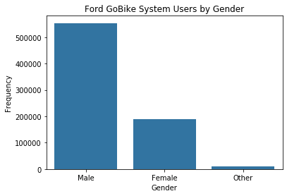

```python
# FordGo Bike System Usage by Gender
gen_order = df_clean['member_gender'].value_counts().index
sb.countplot(data = df_clean, x = 'member_gender', color = base_color, order = gen_order);
plt.xlabel('Gender');
plt.ylabel('Frequency');
plt.title("Ford GoBike System Users by Gender");
```

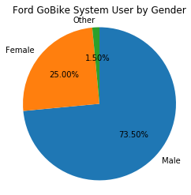

```python
#Let's further plot a pie chart for Gender to clearly see the percentages
gender = df_clean['member_gender'].value_counts()

plt.pie(gender, labels = gender.index, startangle = 90, counterclock = False, autopct= '%1.2f%%');
plt.axis('square')
plt.title('Ford GoBike System User by Gender');
```

- The chart above shows that majority of FordGo Bike users are Males, with 73.5% of the total users

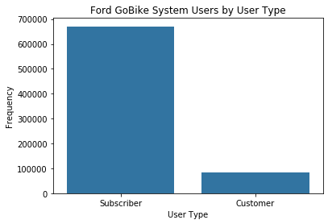

```python
#FordGo Bike System Usage by User Type
gen_order = df_clean['user_type'].value_counts().index
sb.countplot(data = df_clean, x = 'user_type', color = base_color, order = gen_order);
plt.xlabel('User Type');
plt.ylabel('Frequency');
plt.title("Ford GoBike System Users by User Type");
```

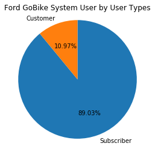

```python
#Let's further plot a pie chart for User Type to clearly see the percentages
users = df_clean['user_type'].value_counts()

plt.pie(users, labels = users.index, startangle = 90, counterclock = False, autopct= '%1.2f%%');
plt.axis('square')
plt.title('Ford GoBike System User by User Types');
```

- The chart above shows that majority of FordGo Bike users are Suscribers with 89% of the total bike users.

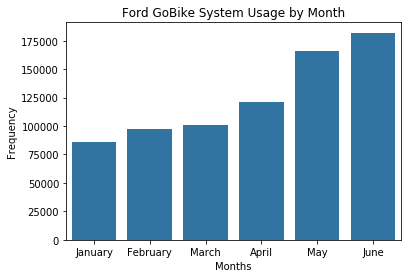

```python
# FordGo Bike System Usage by Month
sb.countplot(data = df_clean, x = 'start_month', color = base_color);
plt.xlabel('Months');
plt.ylabel('Frequency');
plt.title("Ford GoBike System Usage by Month");
```

- The chart above shows that June is the popular Month of biking.

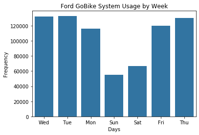

```python
# FordGo Bike System Usage by Week
sb.countplot(data = df_clean, x = 'start_week', color = base_color);
plt.xlabel('Days');
plt.ylabel('Frequency');
plt.title("Ford GoBike System Usage by Week");
```

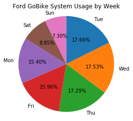

```python
#Let's further plot a pie chart for Weekly usage to clearly see the percentages
week = df_clean['start_week'].value_counts()

plt.pie(week, labels = week.index, startangle = 90, counterclock = False, autopct= '%1.2f%%');
plt.axis('square')
plt.title('Ford GoBike System Usage by Week');
```

- The chart above shows that Tuesdays, Wednesdays and Thursdays are the most popular days with 17.66%, 17.53% and 17.29% respectively. This shows that FordGo Bike users used bikes mostly during working days.

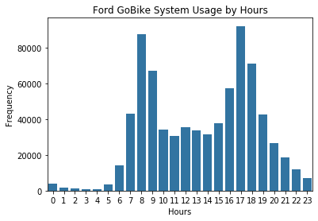

```python
# Hourly usage of the Ford Go Bike System
sb.countplot(data = df_clean, x='start_hour', color = base_color)
plt.xlabel('Hours');
plt.ylabel('Frequency');
plt.title("Ford GoBike System Usage by Hours");
```

- The most usage Hour is 8am and 5pm.

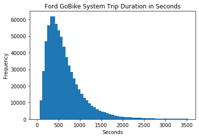

```python
# Usage of the Ford Go Bike System by Seconds
bin = np.arange(0, 3600, 60)
plt.hist(data = df_clean, x = 'duration_sec', bins = bin);
plt.title("Ford GoBike System Trip Duration in Seconds")
plt.xlabel('Seconds')
plt.ylabel('Frequency');
```

- From the histogram, we can see that most FordGo Bike users uses the bikes below 1000 seconds.

### Discuss the distribution(s) of your variable(s) of interest. Were there any unusual points? Did you need to perform any transformations?

> From the above plots, it can be seen that duration in seconds is right skewed. No any unusual point so far.

### Of the features you investigated, were there any unusual distributions? Did you perform any operations on the data to tidy, adjust, or change the form of the data? If so, why did you do this?

> I used the member_birth_year to create member_age. The member_age variable has an unusual value (outlier) which i removed during the cleaning up process.

## Bivariate Exploration

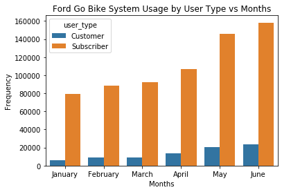

```python
# FordGo Biking System Usage by Month vs User Type
sb.countplot(data = df_clean, x = 'start_month', hue = "user_type");
plt.title('Ford Go Bike System Usage by User Type vs Months');
plt.xlabel('Months');
plt.ylabel('Frequency');
```

- From the above figure, it can be seen clearly that the month of June is the month in which both Subscribers and Customers of Ford Go Bike System use the bikes mostly.

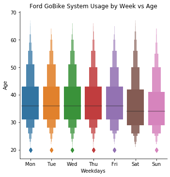

```python
# FordGo Biking System Usage by Week vs Age
weekdays = ['Mon','Tue','Wed','Thu','Fri', 'Sat', 'Sun']
n_week = pd.api.types.CategoricalDtype(ordered = True, categories = weekdays)
df_clean['start_week'] = df_clean['start_week'].astype(n_week)

sb.catplot(x = "start_week", y = "member_age", kind = "boxen", data = df_clean);
plt.title('Ford GoBike System Usage by Week vs Age')
plt.xlabel('Weekdays')
plt.ylabel('Age');
```

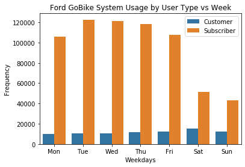

```python
# FordGo Biking System Usage by Week vs User Type
sb.countplot(data = df_clean, x = 'start_week', hue = 'user_type');
plt.title('Ford GoBike System Usage by User Type vs Week')
plt.xlabel('Weekdays')
plt.ylabel('Frequency');
plt.legend();
```

- From the above figure, we can clearly see that Subcribers uses the Ford Go Biking system more than Customers.

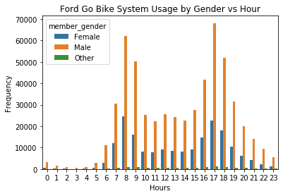

```python
# FordGo Biking System usage by Member Gender vs Hour
sb.countplot(data = df_clean, x = 'start_hour', hue = 'member_gender');
plt.title('Ford Go Bike System Usage by Gender vs Hour');
plt.xlabel('Hours')
plt.ylabel('Frequency');
```

- From the above plot, it can be seen that Males users use the Ford Go Bike System more than Females users in each hour.

### Did you observe any interesting relationships between the other features (not the main feature(s) of interest)?

> Most FordGo Biking System users for both Subscribers and Customers are males.